# ESM 244 Assignment 1: Task 2

Author

Olivia Hemond

```r
library(tidyverse)
library(here)
library(lubridate)
library(tsibble)
library(feasts)
library(fable)
```

# Overview

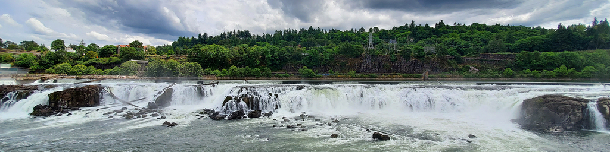

Willamette Falls in Oregon City, OR. Photo credit: PGE

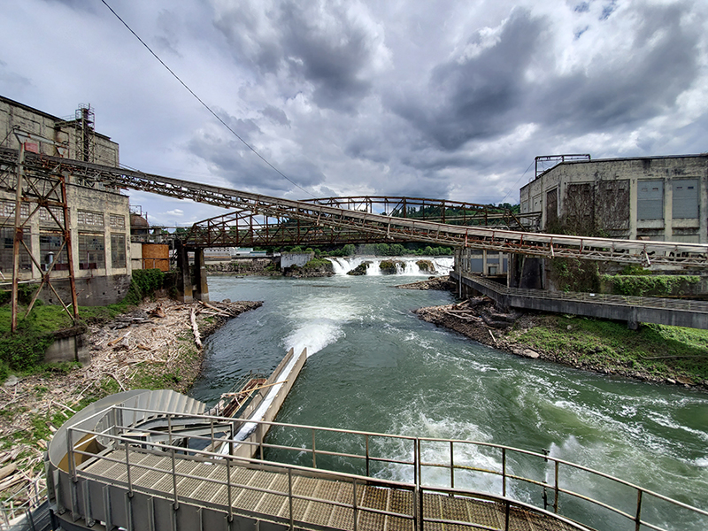

Chute to facilitate fish passage over the falls. Photo credit: PGE

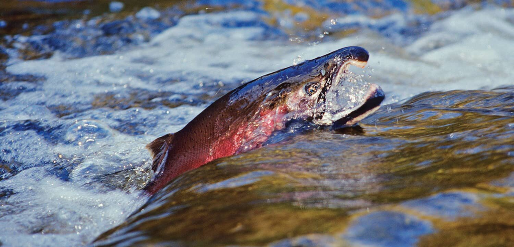

Coho salmon swimming upstream. Photo credit: Wild Salmon Center

This report investigates the passage of coho salmon, coho jacks, and steelhead trout through Willamette Falls from January 2001 through December 2010. The Willamette Falls Fishway consists of three fish ladders that facilitate the movement of fish across the waterfalls. This passage is especially important for migratory species, such as salmon and steelhead trout, which must migrate upstream to spawn. The data used for these analyses come from scientific observations of the fish passing through the ladders of this fishway.

*Data source:* Columbia River DART. DART Adult Passage Counts (Willamette Falls, 2001 - 2010). https://www.cbr.washington.edu/dart/query/adult_graph_text. Accessed January 25, 2023.

```r
### Read in the data
fish_df <- read_csv(here('data/willamette_fish_passage.csv')) %>%
  janitor::clean_names()
```

```r
### Format data as time series
fish_ts <- fish_df %>%
  mutate(date = lubridate::mdy(date)) %>%
  as_tsibble(key = NULL,
             index = date)
```

**Time Series**

```r
### Tidy time series data, with selected species
fish_ts_select <- fish_ts %>%
  select(date, coho, jack_coho, steelhead) %>%
  pivot_longer(cols = coho:steelhead,
               names_to = "species",
               values_to = "count") %>%
  mutate(count = replace_na(count, 0))
```

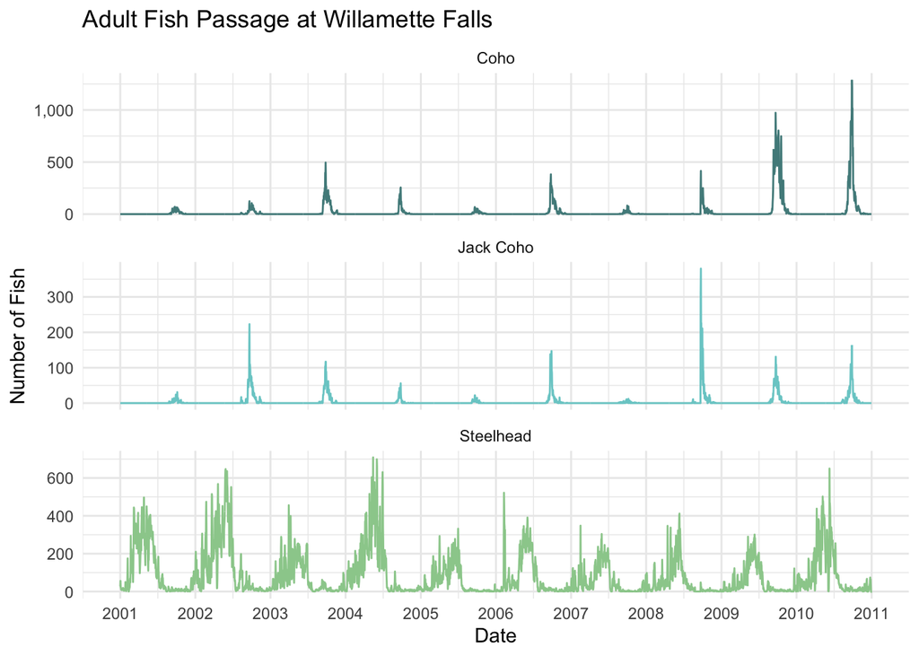

Figure 1: Counts of fish passing through Willamette Falls fishway by type (coho, jack coho, and steelhead), from 2001 to 2010.

```r
ggplot(data = fish_ts_select, aes(x = date, y = count, color = species)) +
  geom_line() +
  labs(x = "Date", y = "Number of Fish", title = "Adult Fish Passage at Willamette Falls") +
  scale_color_manual(values = c('darkslategray4', 'darkslategray3', 'darkseagreen3')) +
  facet_wrap(~ species,
             nrow = 3,
             labeller = labeller(species =
                                   c("coho" = "Coho",
                                     "jack_coho" = "Jack Coho",
                                     "steelhead" = "Steelhead")),
             scales = "free_y") +
  scale_x_date(date_breaks = "1 year", date_labels = "%Y") +
  scale_y_continuous(labels = scales::comma_format()) +
  theme_minimal() +
  theme(legend.position = "none")
```

- All examined fish species pass through the falls annually, at fairly regular intervals.
- The peak passage times for coho and jack coho are aligned, and happen within a fairly short time window.
- Steelhead pass through the falls across a wider time window, with less well-defined peaks, compared to coho and jack coho counts.

**Seasonplot**

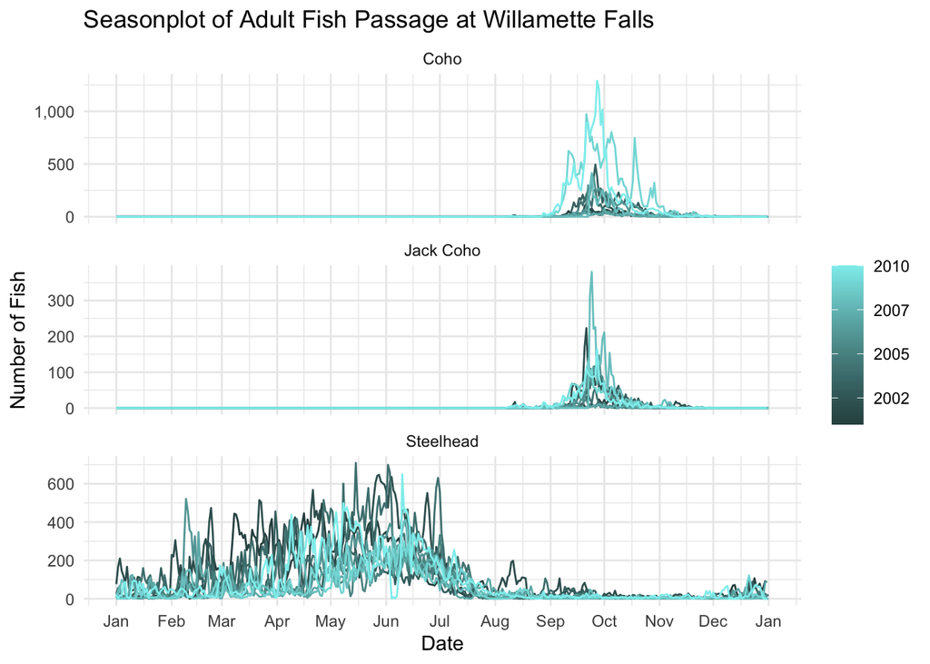

Figure 2: Fish counts at Willamette Falls by season and fish type, from 2001 to 2010. Counts in later years are signified by lighter colors of blue.

```r
fish_ts_select %>%
gg_season(y = count, pal = c("darkslategray","darkslategray2")) +
  labs(x = "Date", y = "Number of Fish",
       title = "Seasonplot of Adult Fish Passage at Willamette Falls") +
  facet_wrap(~ species,
             nrow = 3,
             labeller = labeller(species =
                                   c("coho" = "Coho",
                                     "jack_coho" = "Jack Coho",
                                     "steelhead" = "Steelhead")),
             scales = "free_y") +
  scale_x_date(date_breaks = "1 month", date_labels = "%b") +
  scale_y_continuous(labels = scales::comma_format()) +
  theme_minimal()
```

**Annual Counts**

```r
### Group data by fish type and year
fish_ts_annual <- fish_ts_select %>%
  index_by(year = ~year(.)) %>%
  group_by(species) %>%
  summarize(annual_count = sum(count))
```

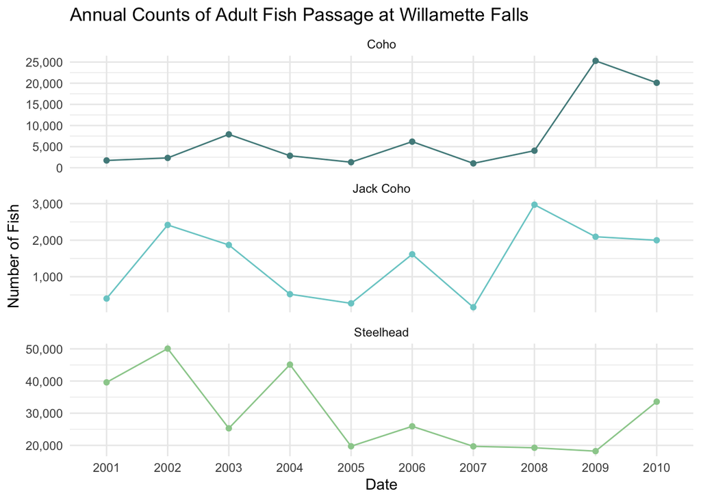

Figure 3: Cumulative counts of each fish type (coho, jack coho, and steelhead) across each year of the study period.

```r
ggplot(data = fish_ts_annual, aes(x = as_factor(year), y = annual_count, color = species, group = species)) +
  geom_point() +
  geom_line() +
  labs(x = "Date", y = "Number of Fish", title = "Annual Counts of Adult Fish Passage at Willamette Falls") +
  scale_color_manual(values = c('darkslategray4', 'darkslategray3', 'darkseagreen3')) +
  facet_wrap(~ species,
             nrow = 3,
             labeller = labeller(species =
                                   c("coho" = "Coho",
                                     "jack_coho" = "Jack Coho",
                                     "steelhead" = "Steelhead")),
             scales = "free_y") +
  scale_y_continuous(labels = scales::comma_format()) +
  theme_minimal() +
  theme(legend.position = "none")
```

- Coho numbers increased noticeably in 2009 and 2010 compared to earlier years.
- Jack coho numbers have fluctuated over the study period. It is unclear whether and how they are correlated to coho counts.
- Steelhead numbers generally declined through the 2000s. However, in 2010 the counts appeared to increase, potentially signally a rebound in population growth.